# Navigation - Report

This notebook contains my report for the first project of the [Deep Reinforcement Learning Nanodegree] for student Sindy Ma (sindyma90@gmail.com)

Github repo: [https://github.com/sindyma/udacity-navigation-p1]

**Sections**: Introduction, Learning algorithm: DQN, Results, Ideas for improvement

## Introduction

In the first project of the Udacity Deep Reinforcement Learning Nanodegree, we are tasked to solve a variation of Unity's Banana environment. In this environment, the agent has a first person view of a walled area. Yellow and purple bananas are falling from the sky. The agent picks up a banana by walking into it.

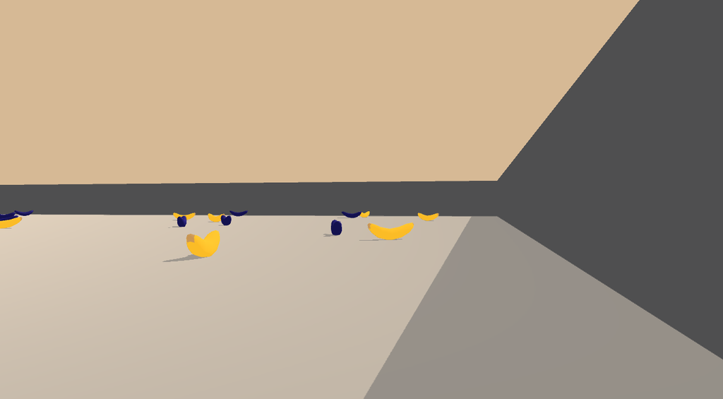

```
Fig 1. Screenshot of the training environment
```

```python
from IPython.display import Image, display
display(Image(filename='banana_env.png', width=500))
print("Fig 1. Screenshot of the training environment")
```

The observation vector is of size 37 and describes the ray-based perception of objects (walls, ground, yellow banana, purple banana) and agent's velocity and agent's forward direction. The number of actions is 4 (move forward, move backward, turn left, turn right). Each time the agent collects a yellow banana, it gets a reward of `+1` and each time it collects a purple banana, it gets a reward of `-1`.

The environment is considered solved when we achieve a score over `13.0` in 100 time steps. In the implementation I describe in this report, this took `600` episodes and the average score was `13.52`.

## Learning algorithm: DQN

DQN is short for Deep Q Network. Let's break down what this means. The Q represents Q Learning, the technique upon which DQN is based. Q Learning is about creating a table that maps states, actions, and potential future rewards (commonly referred to as values). This table, in its optimal and solved state, tells us given a state and action pair, what the potential future reward may be. In this way, we can choose the action that gives us the best possible future reward, i.e. good decision making. The Deep and Network refer to the deep learning and neural networks. Taking all these components together, DQN is Q Learning using Deep Learning Neural Networks.

DQN has many components and we'll dive deeper into what I think are two very key components to understand:

**Reward function**

Each action that our agent takes in an environment will affect it in some way. This may put our agent in a more or less favourable position than before the action is taken. If more favourable, we might like to reward the agent. The function by which this is determined is referred to as the reward function. For example, when training a puppy we might give the puppy a treat when they sit after being told "Sit!" and not give the puppy a treat if they roll over instead. In this case our reward function would be `reward = x * (puppy followed direction flag)` where x is a constant number.

If designed properly the reward function will encourage our agent to make desirable decisions. In complex scenarios the reward function can be very easy to form improperly and this could cause convergence issues or result in undesirable behaviour.

**Discount factor (gamma)**

One of the hyperparameters we can tune, the discount factor dictates how important future rewards are. Future rewards represent the likely cumulative future reward that the agent can possibly receive given their current state. Constantly maximizing your future reward is desirable so as to maximize your overall changes of a great outcome. When the discount factor is 1, your current reward (reward for the immediate following time step) and your future rewards are equally important. When your discount factor is 0, your future reward is completely discounted (multiplied by 0), and not considered at all. Whilst every situation will be different, we will be starting with a discount factor of `0.99` to give the future reward a lot of importance but not equal to the current reward.

### This implementation

After multiple iterations, I landed on the following:

- Training eps: 600
- Epsilon decay rate: 0.99
- Training minibatch size: 32
- Gamma / discount factor: 0.99
- Learning rate: 5e-5
- Update rate (every x steps): 4

Neural network

- 2 hidden layers
- Fully connected layer 1: 64 nodes
- Fully connected layer 2: 32 nodes
- Input layer = 37 input nodes, the size of the state space
- Output layer = 4, the size of the action space

In arriving at this implementation, I experimented with a few elements and here are a few insights.

**There is such a thing as too much training**

In this, and other environments, it is apparent that training too much leads to a) diminishing returns and b) a worse result. I trained the environment for 1,500 episodes and saw that the average score dropped after the 600 episode mark. More importantly, the loss of the model started dramatically increasing in a hockey stick fashion. This implies the agent is becoming more biased and worse at predicting the action-state value.

**Using a conversative learning rate must be balanced with sufficient learning rate**

Using learning rates that decrease as the loss decreases (which can be explored as extensions) seem crucial to training quickly. Without using these techniques, a smaller learning rate is safer. However, a small learning rate must be balanced with sufficient exploration to ensure convergence.

**Minibatch size and update frequency will impact bias early on**

From observation, I concluded that updating the model too frequently early on with large batches will expose the model to bias. This can be mitigated by reducing the batch size and/or exploring more (start exploration later and/or decrease the epsilon decay rate).

**A complicated network architecture can reduce performance and possibly prevent convergence**

I played around with larger and smaller network architectures. Perhaps the problem is quite simple, but many smaller architectures also worked well (e.g. 32, 32) but it seemed that larger architectures increased the number of episodes required to train the model and the loss was well behaved.

**The visual interface is very telling of the training process**

From an untrained agent to a trained agent, the UI was very helpful for demonstrating that the agent had learnt how to move 'smoothly' and with purpose. This really helped me see that the training was working, that the reward had been structured correctly, and that the environment operates as expected. I think the UI is helpful for revealing quirks in the environment and if there are any issues with the way states, actions or the reward have been defined.

## Results

The agent solved in the environment in 600 episodes, achieving an average score of 13.52 and when run for 100 episodes using the trained model, achieved an average score over 16. In Fig 2, the x-axis shows the episodes and y-axis shows the cumulative score of each episode.

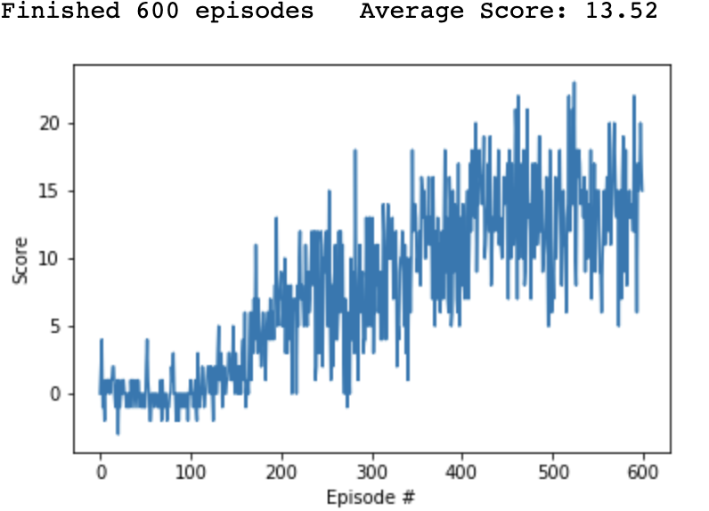

```
Fig 2. Rewards during training
```

```python
from IPython.display import Image, display
display(Image(filename='scores.png', width=400))
print("Fig 2. Rewards during training")
```

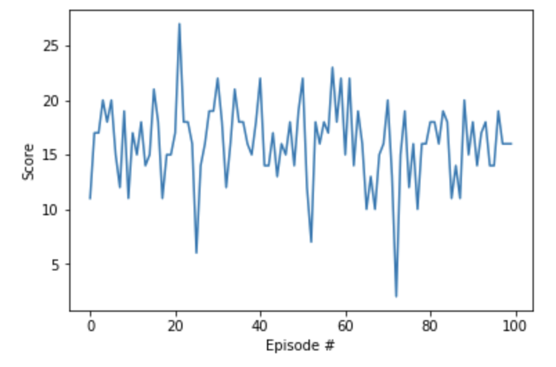

```
Fig 3. Rewards of trained model
```

```python
from IPython.display import Image, display
display(Image(filename='scores_trained_model.png', width=400))
print("Fig 3. Rewards of trained model")
```

## Ideas for improvement

**Ideas for future work**

- Prioritized replay

I think prioritized replay would really help solve this problem faster - particularly towards the end, to meet the goal of a score of 13. As the agent learns to pick up yellow bananas, maximizing the number of yellow bananas becomes the priority. Later experiences include more of this state-action relationship, so prioritizing these memories could really help training performance.

- Epsilon Decay change

An evolving epsilon decay seems crucial to balancing the exploration and exploitation of this problem. I think in this case, in particular, sufficient exploration of the environment before the model decides which objects to try to pick up or reject is important. I hypothesize this is because the environment needs more time to observe that not all bananas are equal.

- Loss

Whilst I attempted to decrease the loss, it is still clear (figure below) that the loss increases during training. I think the magnitude is acceptable but it is still disappointing to see it increase. Further work could be done to decrase the model loss. The x-axis represents each loss reading and the y-axis represents the loss at that point in time. A small comparison is described below. A more comprehensive comparison similar to this but taking into multiple hyper parameters would give us more insight to the relationship of these hyper parameters and their impact on trained agent reward and model loss.

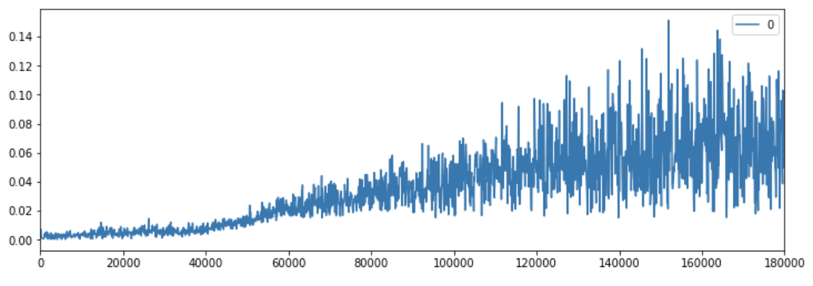

```
Fig 4. Loss during training
```

```python
from IPython.display import Image, display
display(Image(filename='loss.png', width=800))
print("Fig 4. Loss during training")
```

**A comparison of three different learning rates and their impact on loss**

All other hyper parameters held equal, we can see that 5e-5 (the middle image) is a sweet spot for the learning rate when comparing its impact on mode loss when training for the same number of episodes.

```
Fig 5,6,7. Comparison of losses with different learning rates.
```

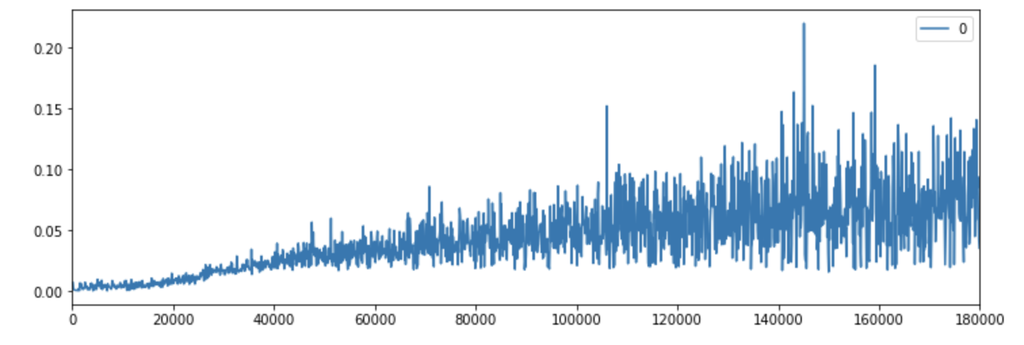

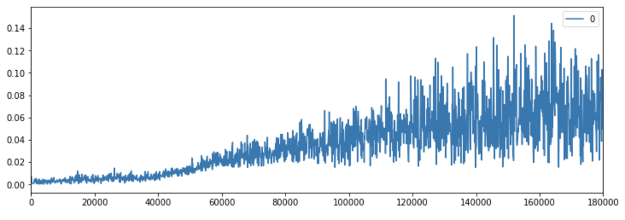

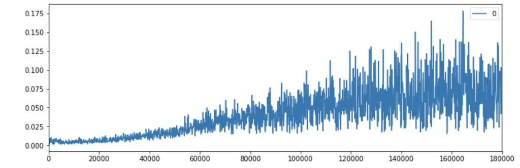

```python
from IPython.display import Image, display
print("Fig 5,6,7. Comparison of losses with different learning rates.")
display(Image(filename='5e-4 loss.png', width=500))
display(Image(filename='loss.png', width=500))
display(Image(filename='5e-6 loss.png', width=500))
```

## Conclusion

In conclusion, the trained agent was able to solve the environment in ~600 episodes. The agent learnt to intelligently move toward yellow bananas and away from purple bananas. This project has given me some intuition around how RL agents should train and how to tweak hyper parameters. Two key things that I would not compromise on are:

- Agent performance: The agent must learn to solve the environment / meet some expectation of the reward. A clear improvement in the reward should be visible in a chart.
- Model loss: The model loss must be acceptable. Ideally, we would also see this decrease in a chart.